# Investigate_a_Dataset_Soccer Database

## Project: Investigating Soccer Database for Seasons 2008/2009 to 2015/2016

- Introduction
- Data Wrangling
- Exploratory Data Analysis
- Conclusions

## Introduction

This soccer database comes from Kaggle. It contains data for soccer matches, players, and teams from 11 European countries from 2008 to 2016.\ There are 7 datasets: country, league, Match, Player, Player Attributes, Team, Team Attributes.\

Questions for Analysis:

- How many matches did each season and each league have?
- Who are the top 3 winning teams for home or away matches? Compare results?
- What does match results convey?
- Which Season had the highest number of winnings by home and away teams?
- Did Celtic team improve its performance throughout the 8 seasons?
- What teams improved the most over the time period?
- What team attributes lead to the most victories?
- Who is the oldest and the youngest players?
- How many players use either preferred right or left foot?
- Who made the most penalties?
- What are the attributes of the best players based on their average overall ratings?

```python
# import the modules
import pandas as pd
import numpy as np
import matplotlib.pyplot as plt
import seaborn as sns
%matplotlib inline
```

```python
# color set used for visualization.
plt.style.use('seaborn')
sns_colors = sns.color_palette("Set3", 12)
```

## Data Wrangling

The data for the indicators were downloaded separately, therefore I had to first clean each dataset and then merge them together.

```python
# Load your data and print out a few lines. Perform operations to inspect data.
# use shape and info()
df_country= pd.read_csv('Country.csv')
df_country.head()
```

|  | id | name |
| --- | --- | --- |
| 0 | 1 | Belgium |
| 1 | 1729 | England |
| 2 | 4769 | France |
| 3 | 7809 | Germany |
| 4 | 10257 | Italy |

```python
df_country.shape
```

```
(11, 2)
```

Country dataset has 11 entries representing 11 countries with their id number and name.

```python
df_country.info()
```

```
<class 'pandas.core.frame.DataFrame'>
RangeIndex: 11 entries, 0 to 10
Data columns (total 2 columns):
 #   Column  Non-Null Count  Dtype
---  ------  --------------  -----
 0   id      11 non-null     int64
 1   name    11 non-null     object
dtypes: int64(1), object(1)
memory usage: 304.0+ bytes
```

There are no null values, but will have to rename columns to "country_id" and "country_name" for consistency and it will be easy to merge with other datasets.

```python
df_league= pd.read_csv('League.csv')
df_league.head()
```

|  | id | country_id | name |
| --- | --- | --- | --- |
| 0 | 1 | 1 | Belgium Jupiler League |
| 1 | 1729 | 1729 | England Premier League |
| 2 | 4769 | 4769 | France Ligue 1 |
| 3 | 7809 | 7809 | Germany 1. Bundesliga |
| 4 | 10257 | 10257 | Italy Serie A |

```python
df_league.shape
```

```
(11, 3)
```

There are 11 entries representing 11 leagues with their respective id number, league full name and country.

```python
df_league.info()
```

```
<class 'pandas.core.frame.DataFrame'>
RangeIndex: 11 entries, 0 to 10
Data columns (total 3 columns):
 #   Column      Non-Null Count  Dtype
---  ------      --------------  -----
 0   id          11 non-null     int64
 1   country_id  11 non-null     int64
 2   name        11 non-null     object
dtypes: int64(2), object(1)
memory usage: 392.0+ bytes
```

Fortunately, no null values, but will have to rename columns to "league_id", 'country_id' and "league_name" for consistency and later for merging. Although the values in both league id and country id are the same, I will not merge them.

```python
df_match= pd.read_csv('Match.csv')
df_match.head()
```

|  | id | country_id | league_id | season | stage | date | match_api_id | home_team_api_id | away_team_api_id | home_team_goal | ... | SJA | VCH | VCD | VCA | GBH | GBD | GBA | BSH | BSD | BSA |
| --- | --- | --- | --- | --- | --- | --- | --- | --- | --- | --- | --- | --- | --- | --- | --- | --- | --- | --- | --- | --- | --- |
| 0 | 1 | 1 | 1 | 2008/2009 | 1 | 2008-08-17 00:00:00 | 492473 | 9987 | 9993 | 1 | ... | 4.00 | 1.65 | 3.40 | 4.50 | 1.78 | 3.25 | 4.00 | 1.73 | 3.40 | 4.20 |
| 1 | 2 | 1 | 1 | 2008/2009 | 1 | 2008-08-16 00:00:00 | 492474 | 10000 | 9994 | 0 | ... | 3.80 | 2.00 | 3.25 | 3.25 | 1.85 | 3.25 | 3.75 | 1.91 | 3.25 | 3.60 |
| 2 | 3 | 1 | 1 | 2008/2009 | 1 | 2008-08-16 00:00:00 | 492475 | 9984 | 8635 | 0 | ... | 2.50 | 2.35 | 3.25 | 2.65 | 2.50 | 3.20 | 2.50 | 2.30 | 3.20 | 2.75 |
| 3 | 4 | 1 | 1 | 2008/2009 | 1 | 2008-08-17 00:00:00 | 492476 | 9991 | 9998 | 5 | ... | 7.50 | 1.45 | 3.75 | 6.50 | 1.50 | 3.75 | 5.50 | 1.44 | 3.75 | 6.50 |
| 4 | 5 | 1 | 1 | 2008/2009 | 1 | 2008-08-16 00:00:00 | 492477 | 7947 | 9985 | 1 | ... | 1.73 | 4.50 | 3.40 | 1.65 | 4.50 | 3.50 | 1.65 | 4.75 | 3.30 | 1.67 |

5 rows × 115 columns

```python
df_match.shape
```

```
(25979, 115)
```

Their are 25979 entries representing number of matches across all 11 leagues and 8 seasons from 2008/2009 till 2015/2016.

```python
df_match.info()
```

```
<class 'pandas.core.frame.DataFrame'>
RangeIndex: 25979 entries, 0 to 25978
Columns: 115 entries, id to BSA
dtypes: float64(96), int64(9), object(10)
memory usage: 22.8+ MB
```

```python
df_match.isnull()
```

|  | id | country_id | league_id | season | stage | date | match_api_id | home_team_api_id | away_team_api_id | home_team_goal | ... | SJA | VCH | VCD | VCA | GBH | GBD | GBA | BSH | BSD | BSA |
| --- | --- | --- | --- | --- | --- | --- | --- | --- | --- | --- | --- | --- | --- | --- | --- | --- | --- | --- | --- | --- | --- |
| 0 | False | False | False | False | False | False | False | False | False | False | ... | False | False | False | False | False | False | False | False | False | False |
| 1 | False | False | False | False | False | False | False | False | False | False | ... | False | False | False | False | False | False | False | False | False | False |
| 2 | False | False | False | False | False | False | False | False | False | False | ... | False | False | False | False | False | False | False | False | False | False |
| 3 | False | False | False | False | False | False | False | False | False | False | ... | False | False | False | False | False | False | False | False | False | False |
| 4 | False | False | False | False | False | False | False | False | False | False | ... | False | False | False | False | False | False | False | False | False | False |
| ... | ... | ... | ... | ... | ... | ... | ... | ... | ... | ... | ... | ... | ... | ... | ... | ... | ... | ... | ... | ... | ... |
| 25974 | False | False | False | False | False | False | False | False | False | False | ... | True | True | True | True | True | True | True | True | True | True |
| 25975 | False | False | False | False | False | False | False | False | False | False | ... | True | True | True | True | True | True | True | True | True | True |
| 25976 | False | False | False | False | False | False | False | False | False | False | ... | True | True | True | True | True | True | True | True | True | True |
| 25977 | False | False | False | False | False | False | False | False | False | False | ... | True | True | True | True | True | True | True | True | True | True |
| 25978 | False | False | False | False | False | False | False | False | False | False | ... | True | True | True | True | True | True | True | True | True | True |

25979 rows × 115 columns

```python
df_match.isnull().sum()
```

```
id                0
country_id        0
league_id         0
season            0
stage             0
              ...
GBD           11817
GBA           11817
BSH           11818
BSD           11818
BSA           11818
Length: 115, dtype: int64
```

Only the first 11 columns don't have any null values. there is no use for the other columns, since there is no clear explanation of what they are or entail. I will drop them.

```python
df_teams= pd.read_csv('Team.csv')
df_teams.head()
```

|  | id | team_api_id | team_fifa_api_id | team_long_name | team_short_name |
| --- | --- | --- | --- | --- | --- |
| 0 | 1 | 9987 | 673.0 | KRC Genk | GEN |
| 1 | 2 | 9993 | 675.0 | Beerschot AC | BAC |
| 2 | 3 | 10000 | 15005.0 | SV Zulte-Waregem | ZUL |
| 3 | 4 | 9994 | 2007.0 | Sporting Lokeren | LOK |
| 4 | 5 | 9984 | 1750.0 | KSV Cercle Brugge | CEB |

```python
df_teams.count()
```

```
id                  299
team_api_id         299
team_fifa_api_id    288
team_long_name      299
team_short_name     299
dtype: int64
```

```python
df_teams.shape
```

```
(299, 5)
```

In the team dataset, there are 299 entries representing 299 teams from 11 countries.

```python
df_teams.info()
```

```
<class 'pandas.core.frame.DataFrame'>
RangeIndex: 299 entries, 0 to 298
Data columns (total 5 columns):
 #   Column            Non-Null Count  Dtype
---  ------            --------------  -----
 0   id                299 non-null    int64
 1   team_api_id       299 non-null    int64
 2   team_fifa_api_id  288 non-null    float64
 3   team_long_name    299 non-null    object
 4   team_short_name   299 non-null    object
dtypes: float64(1), int64(2), object(2)
memory usage: 11.8+ KB
```

Only 'team_fifa_api_id' column has null values. I will drop it, since `team_api_id` column is only common with match dataset.

```python
df_teams_attri= pd.read_csv('Team_Attributes.csv')
df_teams_attri.head()
```

|  | id | team_fifa_api_id | team_api_id | date | buildUpPlaySpeed | buildUpPlaySpeedClass | buildUpPlayDribbling | buildUpPlayDribblingClass | buildUpPlayPassing | buildUpPlayPassingClass | ... | chanceCreationShooting | chanceCreationShootingClass | chanceCreationPositioningClass | defencePressure | defencePressureClass | defenceAggression | defenceAggressionClass | defenceTeamWidth | defenceTeamWidthClass | defenceDefenderLineClass |
| --- | --- | --- | --- | --- | --- | --- | --- | --- | --- | --- | --- | --- | --- | --- | --- | --- | --- | --- | --- | --- | --- |
| 0 | 1 | 434 | 9930 | 2010-02-22 00:00:00 | 60 | Balanced | NaN | Little | 50 | Mixed | ... | 55 | Normal | Organised | 50 | Medium | 55 | Press | 45 | Normal | Cover |
| 1 | 2 | 434 | 9930 | 2014-09-19 00:00:00 | 52 | Balanced | 48.0 | Normal | 56 | Mixed | ... | 64 | Normal | Organised | 47 | Medium | 44 | Press | 54 | Normal | Cover |
| 2 | 3 | 434 | 9930 | 2015-09-10 00:00:00 | 47 | Balanced | 41.0 | Normal | 54 | Mixed | ... | 64 | Normal | Organised | 47 | Medium | 44 | Press | 54 | Normal | Cover |
| 3 | 4 | 77 | 8485 | 2010-02-22 00:00:00 | 70 | Fast | NaN | Little | 70 | Long | ... | 70 | Lots | Organised | 60 | Medium | 70 | Double | 70 | Wide | Cover |
| 4 | 5 | 77 | 8485 | 2011-02-22 00:00:00 | 47 | Balanced | NaN | Little | 52 | Mixed | ... | 52 | Normal | Organised | 47 | Medium | 47 | Press | 52 | Normal | Cover |

5 rows × 25 columns

```python
df_teams_attri.shape
```

```
(1458, 25)
```

```python
df_teams_attri.info()
```

```
<class 'pandas.core.frame.DataFrame'>
RangeIndex: 1458 entries, 0 to 1457
Data columns (total 25 columns):
 #   Column                          Non-Null Count  Dtype
---  ------                          --------------  -----
 0   id                              1458 non-null   int64
 1   team_fifa_api_id                1458 non-null   int64
 2   team_api_id                     1458 non-null   int64
 3   date                            1458 non-null   object
 4   buildUpPlaySpeed                1458 non-null   int64
 5   buildUpPlaySpeedClass           1458 non-null   object
 6   buildUpPlayDribbling            489 non-null    float64
 7   buildUpPlayDribblingClass       1458 non-null   object
 8   buildUpPlayPassing              1458 non-null   int64
 9   buildUpPlayPassingClass         1458 non-null   object
```

[output cut: 17 more lines]

In the teams attributes dataset, there are 1458 entries, only `buildUpPlayDribbling` has null values, so it can be droped.\ `date` column needs to be changed to datetime.\

```python
df_players= pd.read_csv('Player.csv')
df_players.head()
```

|  | id | player_api_id | player_name | player_fifa_api_id | birthday | height | weight |
| --- | --- | --- | --- | --- | --- | --- | --- |
| 0 | 1 | 505942 | Aaron Appindangoye | 218353 | 1992-02-29 00:00:00 | 182.88 | 187 |
| 1 | 2 | 155782 | Aaron Cresswell | 189615 | 1989-12-15 00:00:00 | 170.18 | 146 |
| 2 | 3 | 162549 | Aaron Doran | 186170 | 1991-05-13 00:00:00 | 170.18 | 163 |
| 3 | 4 | 30572 | Aaron Galindo | 140161 | 1982-05-08 00:00:00 | 182.88 | 198 |
| 4 | 5 | 23780 | Aaron Hughes | 17725 | 1979-11-08 00:00:00 | 182.88 | 154 |

```python
df_players.shape
```

```
(11060, 7)
```

```python
df_players.info()
```

```
<class 'pandas.core.frame.DataFrame'>
RangeIndex: 11060 entries, 0 to 11059
Data columns (total 7 columns):
 #   Column              Non-Null Count  Dtype
---  ------              --------------  -----
 0   id                  11060 non-null  int64
 1   player_api_id       11060 non-null  int64
 2   player_name         11060 non-null  object
 3   player_fifa_api_id  11060 non-null  int64
 4   birthday            11060 non-null  object
 5   height              11060 non-null  float64
 6   weight              11060 non-null  int64
dtypes: float64(1), int64(4), object(2)
memory usage: 605.0+ KB
```

11060 players and no null values.

```python
df_players_attri= pd.read_csv('Player_Attributes.csv')
df_players_attri.head(7)
```

|  | id | player_fifa_api_id | player_api_id | date | overall_rating | potential | preferred_foot | attacking_work_rate | defensive_work_rate | crossing | ... | vision | penalties | marking | standing_tackle | sliding_tackle | gk_diving | gk_handling | gk_kicking | gk_positioning | gk_reflexes |
| --- | --- | --- | --- | --- | --- | --- | --- | --- | --- | --- | --- | --- | --- | --- | --- | --- | --- | --- | --- | --- | --- |
| 0 | 1 | 218353 | 505942 | 2016-02-18 00:00:00 | 67.0 | 71.0 | right | medium | medium | 49.0 | ... | 54.0 | 48.0 | 65.0 | 69.0 | 69.0 | 6.0 | 11.0 | 10.0 | 8.0 | 8.0 |
| 1 | 2 | 218353 | 505942 | 2015-11-19 00:00:00 | 67.0 | 71.0 | right | medium | medium | 49.0 | ... | 54.0 | 48.0 | 65.0 | 69.0 | 69.0 | 6.0 | 11.0 | 10.0 | 8.0 | 8.0 |
| 2 | 3 | 218353 | 505942 | 2015-09-21 00:00:00 | 62.0 | 66.0 | right | medium | medium | 49.0 | ... | 54.0 | 48.0 | 65.0 | 66.0 | 69.0 | 6.0 | 11.0 | 10.0 | 8.0 | 8.0 |
| 3 | 4 | 218353 | 505942 | 2015-03-20 00:00:00 | 61.0 | 65.0 | right | medium | medium | 48.0 | ... | 53.0 | 47.0 | 62.0 | 63.0 | 66.0 | 5.0 | 10.0 | 9.0 | 7.0 | 7.0 |
| 4 | 5 | 218353 | 505942 | 2007-02-22 00:00:00 | 61.0 | 65.0 | right | medium | medium | 48.0 | ... | 53.0 | 47.0 | 62.0 | 63.0 | 66.0 | 5.0 | 10.0 | 9.0 | 7.0 | 7.0 |
| 5 | 6 | 189615 | 155782 | 2016-04-21 00:00:00 | 74.0 | 76.0 | left | high | medium | 80.0 | ... | 66.0 | 59.0 | 76.0 | 75.0 | 78.0 | 14.0 | 7.0 | 9.0 | 9.0 | 12.0 |
| 6 | 7 | 189615 | 155782 | 2016-04-07 00:00:00 | 74.0 | 76.0 | left | high | medium | 80.0 | ... | 66.0 | 59.0 | 76.0 | 75.0 | 78.0 | 14.0 | 7.0 | 9.0 | 9.0 | 12.0 |

7 rows × 42 columns

```python
df_players_attri.shape
```

```
(183978, 42)
```

```python
df_players_attri.info()
```

```
<class 'pandas.core.frame.DataFrame'>
RangeIndex: 183978 entries, 0 to 183977
Data columns (total 42 columns):
 #   Column               Non-Null Count   Dtype
---  ------               --------------   -----
 0   id                   183978 non-null  int64
 1   player_fifa_api_id   183978 non-null  int64
 2   player_api_id        183978 non-null  int64
 3   date                 183978 non-null  object
 4   overall_rating       183142 non-null  float64
 5   potential            183142 non-null  float64
 6   preferred_foot       183142 non-null  object
 7   attacking_work_rate  180748 non-null  object
 8   defensive_work_rate  183142 non-null  object
 9   crossing             183142 non-null  float64
```

[output cut: 34 more lines]

With the exception of the first 4 columns, the rest have null values. I noticed that there is multiple entries for each single player in different dates form 2007 till 2016. This explains the 183978 entries.

### General Properties Concluded:

11 countries\ 11 league champions\ 25979 matches\ 299 teams\ 21 team sttributes\ 11060 players\ 38 players attributes

# Data Cleaning

## Changes in `df_country`

````python
# Rename columns in ```df_country``` for consistency.
df_country.rename(columns={'id':'country_id', 'name':'country_name'},inplace=True)
df_country
````

|  | country_id | country_name |
| --- | --- | --- |
| 0 | 1 | Belgium |
| 1 | 1729 | England |
| 2 | 4769 | France |
| 3 | 7809 | Germany |
| 4 | 10257 | Italy |
| 5 | 13274 | Netherlands |
| 6 | 15722 | Poland |
| 7 | 17642 | Portugal |
| 8 | 19694 | Scotland |
| 9 | 21518 | Spain |
| 10 | 24558 | Switzerland |

```python
# Drop country_id column and rename the rest of the columns in df_league.
df_league.rename(columns={'id':'league_id', 'name':'league_name'},inplace=True)
df_league.drop('country_id',axis= 1, inplace= True)
df_league
```

|  | league_id | league_name |
| --- | --- | --- |
| 0 | 1 | Belgium Jupiler League |
| 1 | 1729 | England Premier League |
| 2 | 4769 | France Ligue 1 |
| 3 | 7809 | Germany 1. Bundesliga |
| 4 | 10257 | Italy Serie A |
| 5 | 13274 | Netherlands Eredivisie |
| 6 | 15722 | Poland Ekstraklasa |
| 7 | 17642 | Portugal Liga ZON Sagres |
| 8 | 19694 | Scotland Premier League |
| 9 | 21518 | Spain LIGA BBVA |
| 10 | 24558 | Switzerland Super League |

## Changes in `df_teams`

```python
# Check for any duplicated team name
duplicated= df_teams[df_teams.duplicated('team_long_name')]
duplicated
```

|  | id | team_api_id | team_fifa_api_id | team_long_name | team_short_name |
| --- | --- | --- | --- | --- | --- |
| 24 | 2510 | 274581 | 111560.0 | Royal Excel Mouscron | MOP |
| 183 | 31445 | 8020 | 111429.0 | Polonia Bytom | GOR |
| 199 | 32409 | 8024 | 301.0 | Widzew Łódź | WID |

```python
# Drop the duplicated names.
df_teams.drop([df_teams.index[24], df_teams.index[183], df_teams.index[199]], axis=0, inplace=True)
df_teams.count()
```

```
id                  296
team_api_id         296
team_fifa_api_id    285
team_long_name      296
team_short_name     296
dtype: int64
```

```python
# Drop unneeded columns.
df_teams.drop(['id', 'team_fifa_api_id', 'team_short_name'],axis= 1, inplace= True)
df_teams.head()
```

|  | team_api_id | team_long_name |
| --- | --- | --- |
| 0 | 9987 | KRC Genk |
| 1 | 9993 | Beerschot AC |
| 2 | 10000 | SV Zulte-Waregem |
| 3 | 9994 | Sporting Lokeren |
| 4 | 9984 | KSV Cercle Brugge |

```python
df_teams.rename(columns={'team_api_id':'team_id'},inplace=True)
```

```python
# Save changes.
df_teams.to_csv('teams_clean.csv', index=False)
```

## Changes in `df_teams_attri`

```python
# Add team names column.
team_attribute= df_teams_attri.merge(df_teams, left_on='team_api_id', right_on='team_id', how='inner')

# Drop null values.
team_attribute.dropna(axis=1, inplace=True)
```

```python
# Drop unnecessary columns
team_attribute.drop(['id','team_fifa_api_id', 'team_api_id'], axis=1, inplace=True)
```

```python
# Rearrange columns.
team_attribute= team_attribute[['team_id','team_long_name','date', 'buildUpPlaySpeed', 'buildUpPlaySpeedClass',
       'buildUpPlayDribblingClass', 'buildUpPlayPassing',
       'buildUpPlayPassingClass', 'buildUpPlayPositioningClass',
       'chanceCreationPassing', 'chanceCreationPassingClass',
       'chanceCreationCrossing', 'chanceCreationCrossingClass',
       'chanceCreationShooting', 'chanceCreationShootingClass',
       'chanceCreationPositioningClass', 'defencePressure',
       'defencePressureClass', 'defenceAggression', 'defenceAggressionClass',
       'defenceTeamWidth', 'defenceTeamWidthClass', 'defenceDefenderLineClass']]
```

```python
# Change date column to datetime.
team_attribute['date']= pd.to_datetime(team_attribute['date'])
```

```python
#drop non nonnumeric columns and team id.
team_attribute.drop(['team_id','buildUpPlaySpeedClass','buildUpPlayPassingClass','buildUpPlayDribblingClass','buildUpPlayPositioningClass',
                     'chanceCreationPassingClass','chanceCreationCrossingClass','chanceCreationShootingClass',
                     'chanceCreationPositioningClass','defencePressureClass','defenceAggressionClass',
                    'defenceTeamWidthClass','defenceDefenderLineClass'],axis= 1, inplace= True)
```

```python
# Save changes
team_attribute.to_csv('team_attribute_clean.csv', index=False)
```

## Changes in `df_match`

```python
# I am only interested in the first 11 columns and the reset is dropped
df_match.drop(df_match.loc[:, 'home_player_X1':'BSA'], axis=1, inplace=True)
```

```python
# Add country_name from df_country by using merge() and create new dataframe match.
match= pd.merge(df_match, df_country, on='country_id', how='inner')
```

```python
# Add league_name from df_league by using merge().
match= match.merge(df_league, on='league_id', how='inner')
```

```python
# Add team names as home_team and away_team using merge with df_teams.
```

```python
# Create and add home_team.
match= match.merge(df_teams, left_on='home_team_api_id', right_on='team_id',how='inner')
match.rename(columns={'team_long_name':'home_team'},inplace=True)
```

```python
# Create and add away_team.
match= match.merge(df_teams, left_on='away_team_api_id', right_on='team_id',how='left')
match.rename(columns={'team_long_name':'away_team'},inplace=True)
```

```python
match.head()
```

|  | id | country_id | league_id | season | stage | date | match_api_id | home_team_api_id | away_team_api_id | home_team_goal | away_team_goal | country_name | league_name | team_id_x | home_team | team_id_y | away_team |
| --- | --- | --- | --- | --- | --- | --- | --- | --- | --- | --- | --- | --- | --- | --- | --- | --- | --- |
| 0 | 1 | 1 | 1 | 2008/2009 | 1 | 2008-08-17 00:00:00 | 492473 | 9987 | 9993 | 1 | 1 | Belgium | Belgium Jupiler League | 9987 | KRC Genk | 9993.0 | Beerschot AC |
| 1 | 29 | 1 | 1 | 2008/2009 | 12 | 2008-11-15 00:00:00 | 492583 | 9987 | 9999 | 1 | 1 | Belgium | Belgium Jupiler League | 9987 | KRC Genk | 9999.0 | KSV Roeselare |
| 2 | 47 | 1 | 1 | 2008/2009 | 14 | 2008-11-29 00:00:00 | 492651 | 9987 | 9984 | 3 | 2 | Belgium | Belgium Jupiler League | 9987 | KRC Genk | 9984.0 | KSV Cercle Brugge |
| 3 | 65 | 1 | 1 | 2008/2009 | 16 | 2008-12-13 00:00:00 | 492713 | 9987 | 9986 | 1 | 0 | Belgium | Belgium Jupiler League | 9987 | KRC Genk | 9986.0 | Sporting Charleroi |
| 4 | 94 | 1 | 1 | 2008/2009 | 19 | 2009-01-24 00:00:00 | 492805 | 9987 | 9998 | 2 | 0 | Belgium | Belgium Jupiler League | 9987 | KRC Genk | 9998.0 | RAEC Mons |

```python
# Drop unnecessary columns in match
match.drop(['id','country_id', 'league_id',
            'home_team_api_id','away_team_api_id',
            'team_id_x','team_id_y'], axis=1, inplace=True)
```

```python
# Rearrange the remaining columns.
match= match[['country_name','league_name','season', 'stage', 'date', 'match_api_id',
              'home_team','away_team','home_team_goal','away_team_goal']]
```

```python
match.head()
```

|  | country_name | league_name | season | stage | date | match_api_id | home_team | away_team | home_team_goal | away_team_goal |
| --- | --- | --- | --- | --- | --- | --- | --- | --- | --- | --- |
| 0 | Belgium | Belgium Jupiler League | 2008/2009 | 1 | 2008-08-17 00:00:00 | 492473 | KRC Genk | Beerschot AC | 1 | 1 |
| 1 | Belgium | Belgium Jupiler League | 2008/2009 | 12 | 2008-11-15 00:00:00 | 492583 | KRC Genk | KSV Roeselare | 1 | 1 |
| 2 | Belgium | Belgium Jupiler League | 2008/2009 | 14 | 2008-11-29 00:00:00 | 492651 | KRC Genk | KSV Cercle Brugge | 3 | 2 |
| 3 | Belgium | Belgium Jupiler League | 2008/2009 | 16 | 2008-12-13 00:00:00 | 492713 | KRC Genk | Sporting Charleroi | 1 | 0 |
| 4 | Belgium | Belgium Jupiler League | 2008/2009 | 19 | 2009-01-24 00:00:00 | 492805 | KRC Genk | RAEC Mons | 2 | 0 |

```python
# Creat column for match result and add it to match dataframe.
def result(match):
    if match['home_team_goal'] > match['away_team_goal']:
        return match['home_team']
    elif match['home_team_goal'] < match['away_team_goal']:
        return match['away_team']
    elif match['home_team_goal'] == match['away_team_goal']:
        return 'Tie'

match['match_result']= match.apply(result, axis=1)
```

```python
match.head()
```

|  | country_name | league_name | season | stage | date | match_api_id | home_team | away_team | home_team_goal | away_team_goal | match_result |
| --- | --- | --- | --- | --- | --- | --- | --- | --- | --- | --- | --- |
| 0 | Belgium | Belgium Jupiler League | 2008/2009 | 1 | 2008-08-17 00:00:00 | 492473 | KRC Genk | Beerschot AC | 1 | 1 | Tie |
| 1 | Belgium | Belgium Jupiler League | 2008/2009 | 12 | 2008-11-15 00:00:00 | 492583 | KRC Genk | KSV Roeselare | 1 | 1 | Tie |
| 2 | Belgium | Belgium Jupiler League | 2008/2009 | 14 | 2008-11-29 00:00:00 | 492651 | KRC Genk | KSV Cercle Brugge | 3 | 2 | KRC Genk |
| 3 | Belgium | Belgium Jupiler League | 2008/2009 | 16 | 2008-12-13 00:00:00 | 492713 | KRC Genk | Sporting Charleroi | 1 | 0 | KRC Genk |
| 4 | Belgium | Belgium Jupiler League | 2008/2009 | 19 | 2009-01-24 00:00:00 | 492805 | KRC Genk | RAEC Mons | 2 | 0 | KRC Genk |

```python
#check for null values.
match.isnull().sum()
```

```
country_name        0
league_name         0
season              0
stage               0
date                0
match_api_id        0
home_team           0
away_team         187
home_team_goal      0
away_team_goal      0
match_result       38
dtype: int64
```

```python
match.dropna(axis=0, inplace=True)
```

```python
match.isnull().sum()
```

```
country_name      0
league_name       0
season            0
stage             0
date              0
match_api_id      0
home_team         0
away_team         0
home_team_goal    0
away_team_goal    0
match_result      0
dtype: int64
```

```python
#check for duplicates.
match.duplicated().sum()
```

```
0
```

```python
match.to_csv('match_clean.csv', index=False)
```

## Changes in `df_players`

```python
#Remove id and player_fifa_api_id.
df_players.drop(['id','player_fifa_api_id'], axis=1, inplace=True)
```

```python
#Convert birthday column to datetime.
df_players['birthday']= pd.to_datetime(df_players['birthday'])
```

```python
# Rename column player_api_id to player_id
df_players.rename(columns={'player_api_id':'player_id'},inplace=True)
```

```python
df_players.head()
```

|  | player_id | player_name | birthday | height | weight |
| --- | --- | --- | --- | --- | --- |
| 0 | 505942 | Aaron Appindangoye | 1992-02-29 | 182.88 | 187 |
| 1 | 155782 | Aaron Cresswell | 1989-12-15 | 170.18 | 146 |
| 2 | 162549 | Aaron Doran | 1991-05-13 | 170.18 | 163 |
| 3 | 30572 | Aaron Galindo | 1982-05-08 | 182.88 | 198 |
| 4 | 23780 | Aaron Hughes | 1979-11-08 | 182.88 | 154 |

```python
df_players.dtypes
```

```
player_id               int64
player_name            object
birthday       datetime64[ns]
height                float64
weight                  int64
dtype: object
```

```python
df_players.isnull().sum()
```

```
player_id      0
player_name    0
birthday       0
height         0
weight         0
dtype: int64
```

```python
df_players.duplicated().sum()
```

```
0
```

## Changes in `df_players_attri`

```python
# Drop all null values.
df_players_attri.dropna(inplace=True)
```

```python
# Drop id and player_fifa_api_id
df_players_attri.drop(['id','player_fifa_api_id'], axis=1, inplace=True)
```

```python
# Rename column player_api_id to player_id
df_players_attri.rename(columns={'player_api_id':'player_id'},inplace=True)
```

```python
#Convert date column to datetime.
df_players_attri['date']= pd.to_datetime(df_players_attri['date'])
```

```python
# Merge df_players and df_players_attri
players= df_players_attri.merge(df_players, left_on='player_id', right_on='player_id',how='inner')
```

```python
# Rearrange columns.
players= players[['player_id','player_name','birthday', 'height', 'weight','date','overall_rating','potential',
                  'preferred_foot','attacking_work_rate','defensive_work_rate','crossing','finishing','free_kick_accuracy',
                 'long_passing','ball_control','acceleration','sprint_speed','agility','reactions','balance','shot_power',
                 'jumping','stamina','strength','long_shots','aggression','interceptions','positioning','vision','penalties',
                  'marking','standing_tackle','sliding_tackle','gk_diving','gk_handling','gk_kicking','gk_positioning','gk_reflexes']]
```

```python
players.head()
```

|  | player_id | player_name | birthday | height | weight | date | overall_rating | potential | preferred_foot | attacking_work_rate | ... | vision | penalties | marking | standing_tackle | sliding_tackle | gk_diving | gk_handling | gk_kicking | gk_positioning | gk_reflexes |
| --- | --- | --- | --- | --- | --- | --- | --- | --- | --- | --- | --- | --- | --- | --- | --- | --- | --- | --- | --- | --- | --- |
| 0 | 505942 | Aaron Appindangoye | 1992-02-29 | 182.88 | 187 | 2016-02-18 | 67.0 | 71.0 | right | medium | ... | 54.0 | 48.0 | 65.0 | 69.0 | 69.0 | 6.0 | 11.0 | 10.0 | 8.0 | 8.0 |
| 1 | 505942 | Aaron Appindangoye | 1992-02-29 | 182.88 | 187 | 2015-11-19 | 67.0 | 71.0 | right | medium | ... | 54.0 | 48.0 | 65.0 | 69.0 | 69.0 | 6.0 | 11.0 | 10.0 | 8.0 | 8.0 |
| 2 | 505942 | Aaron Appindangoye | 1992-02-29 | 182.88 | 187 | 2015-09-21 | 62.0 | 66.0 | right | medium | ... | 54.0 | 48.0 | 65.0 | 66.0 | 69.0 | 6.0 | 11.0 | 10.0 | 8.0 | 8.0 |
| 3 | 505942 | Aaron Appindangoye | 1992-02-29 | 182.88 | 187 | 2015-03-20 | 61.0 | 65.0 | right | medium | ... | 53.0 | 47.0 | 62.0 | 63.0 | 66.0 | 5.0 | 10.0 | 9.0 | 7.0 | 7.0 |
| 4 | 505942 | Aaron Appindangoye | 1992-02-29 | 182.88 | 187 | 2007-02-22 | 61.0 | 65.0 | right | medium | ... | 53.0 | 47.0 | 62.0 | 63.0 | 66.0 | 5.0 | 10.0 | 9.0 | 7.0 | 7.0 |

5 rows × 39 columns

```python
# Save changes.
players.to_csv('players_clean.csv', index=False)
```

## Exploratory Data Analysis

### How many matches did each season have?

```python
df=match['season'].value_counts().sort_values(ascending=True)
df
```

```
2013/2014    2974
2011/2012    3162
2010/2011    3202
2012/2013    3202
2009/2010    3230
2014/2015    3265
2015/2016    3266
2008/2009    3296
Name: season, dtype: int64
```

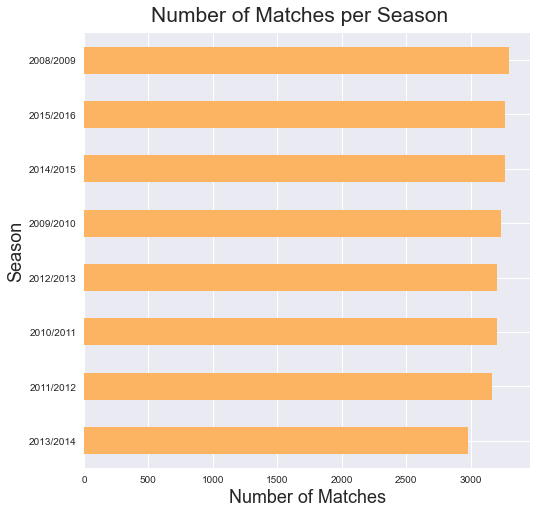

```python
#Plot results.
colors= sns_colors[5]
df.plot(kind='barh', color=colors, figsize=(8,8));
plt.figtext(.5,.9,'Number of Matches per Season', fontsize=21, ha='center');
plt.xlabel('Number of Matches', fontsize=18);
plt.ylabel('Season', fontsize=18);
```

Throughout the 8 seasons, 2008/2009 had the most number of matches while 2013/2014 had the lowest number of matches.

### How many matches did each league have?

```python
df1= match['league_name'].value_counts().sort_values(ascending=True)
df1
```

```
Switzerland Super League    1422
Poland Ekstraklasa          1598
Belgium Jupiler League      1668
Scotland Premier League     1824
Portugal Liga ZON Sagres    2052
Netherlands Eredivisie      2448
Germany 1. Bundesliga       2448
Italy Serie A               3017
England Premier League      3040
France Ligue 1              3040
Spain LIGA BBVA             3040
Name: league_name, dtype: int64
```

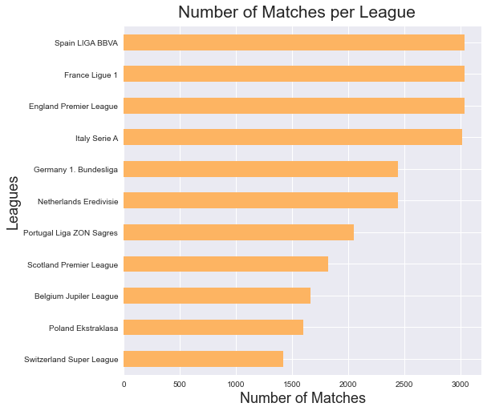

```python
#Plot results.
colors= sns_colors[5]
df1.plot(kind='barh', color=colors, figsize=(8,8))
plt.figtext(.5,.9,'Number of Matches per League', fontsize=21, ha='center');
plt.xlabel('Number of Matches', fontsize=18);
plt.ylabel('Leagues', fontsize=18);
```

England Premier League, Spain LIGA BBVA, France Ligue 1 have the highest number of matches throughout the 8 seasons.

### Who are the top 3 winning teams for home or away matches? Compare results?

```python
# Top 3 winning home teams.
win_home= match.query('home_team == match_result')
home= win_home['match_result'].value_counts().sort_values(ascending=False)[:3]
print(home)
```

```
FC Barcelona      131
Real Madrid CF    129
Celtic            120
Name: match_result, dtype: int64
```

```python
# Top 3 winning away teams.
win_away= match.query('away_team == match_result')
away= win_away['match_result'].value_counts().sort_values(ascending=False)[:3]
print(away)
```

```
FC Barcelona      103
Real Madrid CF     99
Celtic             98
Name: match_result, dtype: int64
```

`FC Barcelona`, `Real Madrid CF`,and `Celtic` are top 3 winning teams both as a home team and away team with a difference in winning results.So, lets compare the results.

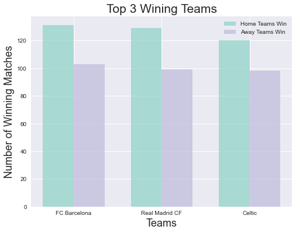

```python
# Compare the results.
ind = np.arange(len(home))
width = 0.35
fig = plt.figure(figsize = (8, 6));

home_bars = plt.bar(ind, home, width, color=sns_colors[0], alpha=.7, label='Home Teams Win');
away_bars = plt.bar(ind+width, away, width, color=sns_colors[2], alpha=.7, label='Away Teams Win');

locations = ind + width / 2
labels = ['FC Barcelona', 'Real Madrid CF', 'Celtic']
plt.xticks(locations, labels);

plt.ylabel('Number of Winning Matches', fontsize=18);
plt.xlabel('Teams', fontsize=18);
plt.title('Top 3 Wining Teams', fontsize=21);

plt.legend();
```

Top teams who play in their homeland have more winnings than playing away from their homeland.

### What does match results convey?

To answer this, we will have to calculate total wins by home teams and away teams, and also total number of ties. Then, we'll get their percentages and plot them for visual comparison.

```python
# Total wins by home teams.
total_home_wins= win_home['match_result'].count()

# Total wins by away teams.
total_away_wins= win_away['match_result'].count()

# Total ties.
tie= match.query('match_result == "Tie"')
total_tie= tie['match_result'].count()

# Total matches
total_matches= match['match_result'].count()
```

```python
# Percentage of home teams winnings.
home_proportion= (total_home_wins/total_matches)*100
home_proportion
```

```
45.872563190998946
```

```python
# Percentage of away teams winnings.
away_proportion= (total_away_wins/total_matches)*100
away_proportion
```

```
28.800250029300305
```

```python
# Percentage of total ties.
tie_proportion= (total_tie/total_matches)*100
tie_proportion
```

```
25.327186779700746
```

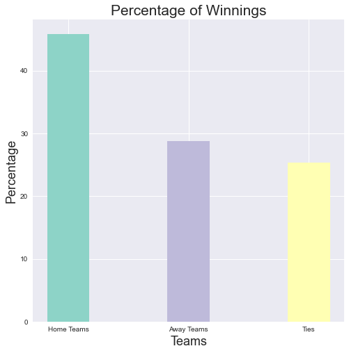

```python
# Plot results using bar chart.
data = {'Home Teams':home_proportion, 'Away Teams':away_proportion, 'Ties':tie_proportion}
keys = data.keys()
values = data.values()

fig = plt.figure(figsize = (8, 8));

plt.bar(keys, values, color =[sns_colors[0], sns_colors[2], sns_colors[1]],
        width = 0.35);

plt.xlabel("Teams", fontsize=18);
plt.ylabel("Percentage", fontsize=18);
plt.title("Percentage of Winnings", fontsize=21);
```

### Which Season had the highest number of winnings by home and away teams?

```python
# The season with highest number of home teams winning
home_season = win_home.groupby(['season']).count()
print('The season with highest number of home teams winning:\n{}'.format(home_season['match_result'].nlargest(1)))
```

```
The season with highest number of home teams winning:
season
2008/2009    1550
Name: match_result, dtype: int64
```

```python
# The season with highest number of away teams winning.
away_season = win_away.groupby(['season']).count()
print('The season with highest number of away teams winning:\n{}'.format(away_season['match_result'].nlargest(1)))
```

```
The season with highest number of away teams winning:
season
2015/2016    994
Name: match_result, dtype: int64
```

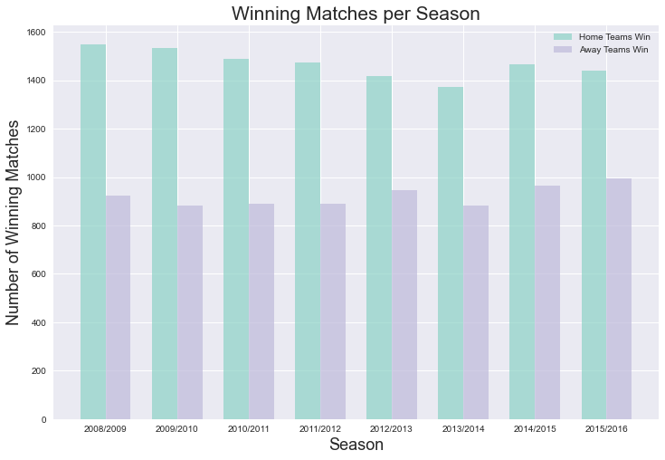

```python
# Plot the results.

ind = np.arange(len(away_season['match_result']))
width = 0.35
fig = plt.subplots(figsize =(12, 8))

home_bars = plt.bar(ind, home_season['match_result'], width, color=sns_colors[0], alpha=.7, label='Home Teams Win');
away_bars = plt.bar(ind+width, away_season['match_result'], width, color=sns_colors[2], alpha=.7, label='Away Teams Win');

locations = ind + width / 2
labels = ['2008/2009', '2009/2010', '2010/2011','2011/2012','2012/2013','2013/2014','2014/2015','2015/2016']
plt.xticks(locations, labels);

plt.ylabel('Number of Winning Matches', fontsize=18);
plt.xlabel('Season', fontsize=18);
plt.title('Winning Matches per Season', fontsize=21);

plt.legend();
```

### Did Celtic team improve its performance throughout the 8 seasons?

```python
# Create a dataframe with match results end with Celtic winning.
df4= match.loc[match['match_result']== 'Celtic']
# Get number of winning matches per season for Celtic
df5= df4['season'].value_counts()
```

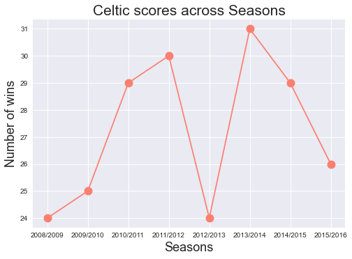

```python
# Plot results
season= ['2008/2009','2009/2010','2010/2011','2011/2012','2012/2013','2013/2014','2014/2015','2015/2016']
heights = df5.reindex(season)
labels = season

plt.plot(labels, heights, color=sns_colors[3], marker='o', markerfacecolor=sns_colors[3], markersize=12);
plt.title('Celtic scores across Seasons', fontsize=21)
plt.xlabel('Seasons', fontsize=18);
plt.ylabel('Number of wins', fontsize=18);
```

Celtic team's performance fluctuated across the 8 seasons. They started with 24 wins in 2008/2009 and gradually increased till 2011/2012 achieving 30 wins. They had a fallout in 2012/2013 with 24 wins. In 2013/2014, they improved significantly achieveing 31 wins. Their performance started to drop gradually ending with 26 wins in 2015/2016.

### What are the teams that improved the most over the time period?

To do this, I will have to calculate mean difference of total goal scores between two seasons which will be 2008/2009 and 2015/2016. First,I will have to get the mean of total goal scores seperately. Second, get their difference.

```python
#2008/2009.
match_2008= match.query('season == "2008/2009"')
match_2008.info()
```

```
<class 'pandas.core.frame.DataFrame'>
Int64Index: 3296 entries, 0 to 25337
Data columns (total 11 columns):
 #   Column          Non-Null Count  Dtype
---  ------          --------------  -----
 0   country_name    3296 non-null   object
 1   league_name     3296 non-null   object
 2   season          3296 non-null   object
 3   stage           3296 non-null   int64
 4   date            3296 non-null   object
 5   match_api_id    3296 non-null   int64
 6   home_team       3296 non-null   object
 7   away_team       3296 non-null   object
 8   home_team_goal  3296 non-null   int64
 9   away_team_goal  3296 non-null   int64
 10  match_result    3296 non-null   object
dtypes: int64(4), object(7)
memory usage: 309.0+ KB
```

```python
# Calculate home teams mean goal scores.
home_2008= match_2008.groupby(['home_team'])['home_team_goal'].mean()
# Calculate away teams mean goal scores.
away_2008= match_2008.groupby(['away_team'])['away_team_goal'].mean()
# Add them to get the total goal scores for the whole season.
total_2008= (home_2008 + away_2008)/2
total_2008.head()
```

```
home_team
1. FC Köln       1.029412
AC Bellinzona    1.222222
ADO Den Haag     1.205882
AJ Auxerre       0.921053
AS Monaco        1.078947
dtype: float64
```

```python
#2015/2016.
match_2015= match.query('season == "2015/2016"')
match_2015.info()
```

```
<class 'pandas.core.frame.DataFrame'>
Int64Index: 3266 entries, 91 to 25783
Data columns (total 11 columns):
 #   Column          Non-Null Count  Dtype
---  ------          --------------  -----
 0   country_name    3266 non-null   object
 1   league_name     3266 non-null   object
 2   season          3266 non-null   object
 3   stage           3266 non-null   int64
 4   date            3266 non-null   object
 5   match_api_id    3266 non-null   int64
 6   home_team       3266 non-null   object
 7   away_team       3266 non-null   object
 8   home_team_goal  3266 non-null   int64
 9   away_team_goal  3266 non-null   int64
 10  match_result    3266 non-null   object
dtypes: int64(4), object(7)
memory usage: 306.2+ KB
```

```python
# Calculate home teams mean goal scores.
home_2015= match_2015.groupby(['home_team'])['home_team_goal'].mean()
# Calculate away teams mean goal scores.
away_2015= match_2015.groupby(['away_team'])['away_team_goal'].mean()
# Add them to get the total goal scores for the whole season.
total_2015= (home_2015 + away_2015)/2
total_2015.head()
```

```
home_team
1. FC Köln          1.117647
1. FSV Mainz 05     1.352941
ADO Den Haag        1.411765
AS Monaco           1.500000
AS Saint-Étienne    1.105263
dtype: float64
```

```python
# Get the difference between 2008 & 2015.
difference= total_2015 - total_2008
difference.head()
```

```
home_team
1. FC Köln         0.088235
1. FSV Mainz 05         NaN
AC Bellinzona           NaN
ADO Den Haag       0.205882
AJ Auxerre              NaN
dtype: float64
```

Since there is difference in number of matches between 2008/2009 and 2015/2016, there will be NaN values will conducting the necessary calculations. Thus, we will have to drop them.

```python
difference.dropna(inplace=True)
```

```python
# Top 10 teams who achieved improvements throughout the 8 seasons
difference.sort_values(ascending=False)[:10]
```

```
home_team
Paris Saint-Germain         1.394737
Cracovia                    1.107143
Piast Gliwice               1.000000
Napoli                      0.973684
Borussia Mönchengladbach    0.823529
Sporting CP                 0.823529
SL Benfica                  0.788235
Real Madrid CF              0.710526
Borussia Dortmund           0.647059
Tottenham Hotspur           0.631579
dtype: float64
```

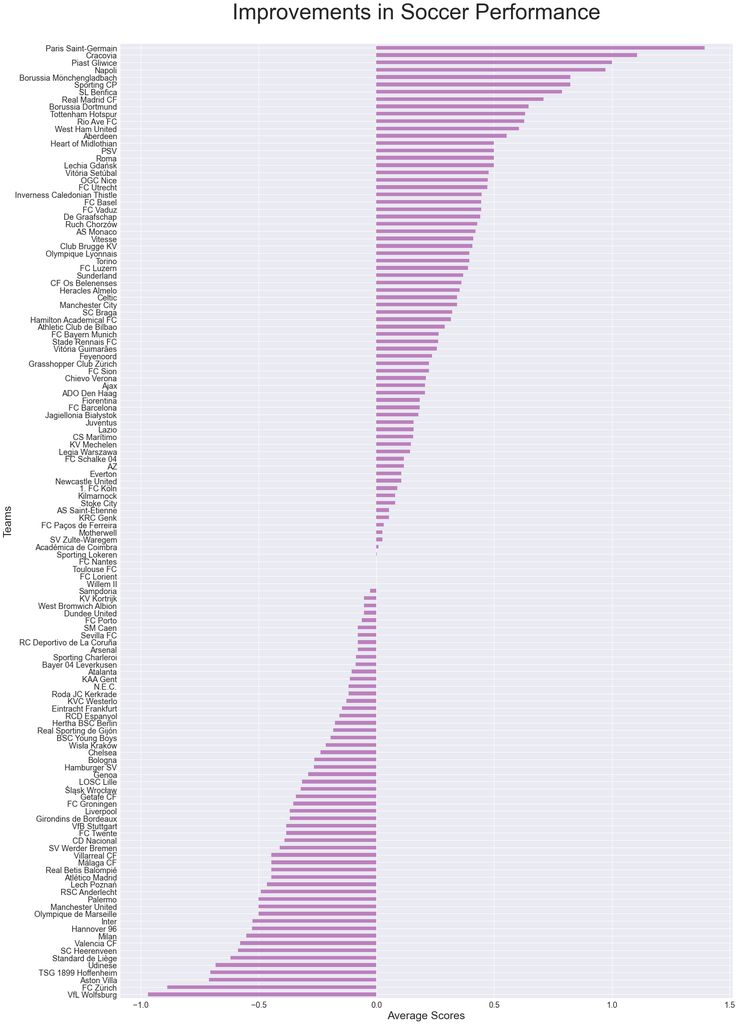

```python
# Plot results
colors= sns_colors[9]
difference.sort_values(ascending=True).plot(kind='barh',fontsize=18,color=colors, figsize=(25,40));
plt.figtext(.5,.9,'Improvements in Soccer Performance', fontsize=50, ha='center')
plt.xlabel('Average Scores', fontsize=25);
plt.ylabel('Teams', fontsize=25);
```

### What team attributes lead to the most victories?

```python
# top three teams throughout the 8 seasons.
top= match['match_result'].value_counts().sort_values(ascending=False)[1:4]
top
```

```
FC Barcelona      234
Real Madrid CF    228
Celtic            218
Name: match_result, dtype: int64
```

```python
team_attribute.describe()
```

|  | buildUpPlaySpeed | buildUpPlayPassing | chanceCreationPassing | chanceCreationCrossing | chanceCreationShooting | defencePressure | defenceAggression | defenceTeamWidth |
| --- | --- | --- | --- | --- | --- | --- | --- | --- |
| count | 1451.000000 | 1451.000000 | 1451.000000 | 1451.000000 | 1451.000000 | 1451.000000 | 1451.000000 | 1451.000000 |
| mean | 52.448656 | 48.456237 | 52.170227 | 53.732598 | 53.964163 | 46.035837 | 49.254307 | 52.164714 |
| std | 11.537493 | 10.880225 | 10.354907 | 11.073742 | 10.343018 | 10.224249 | 9.725727 | 9.582082 |
| min | 20.000000 | 20.000000 | 21.000000 | 20.000000 | 22.000000 | 23.000000 | 24.000000 | 29.000000 |
| 25% | 45.000000 | 40.000000 | 46.000000 | 47.000000 | 48.000000 | 39.000000 | 44.000000 | 47.000000 |
| 50% | 52.000000 | 50.000000 | 52.000000 | 53.000000 | 53.000000 | 45.000000 | 48.000000 | 52.000000 |
| 75% | 62.000000 | 55.000000 | 59.000000 | 62.000000 | 61.000000 | 51.000000 | 55.000000 | 58.000000 |
| max | 80.000000 | 80.000000 | 80.000000 | 80.000000 | 80.000000 | 72.000000 | 72.000000 | 73.000000 |

On a whole scale, there are total 1451 entries for each attribute. Overall mean scores is between 46 and 53.9. Maximum score recorded is 80 and minimum score recorded is 20 across all attributes.

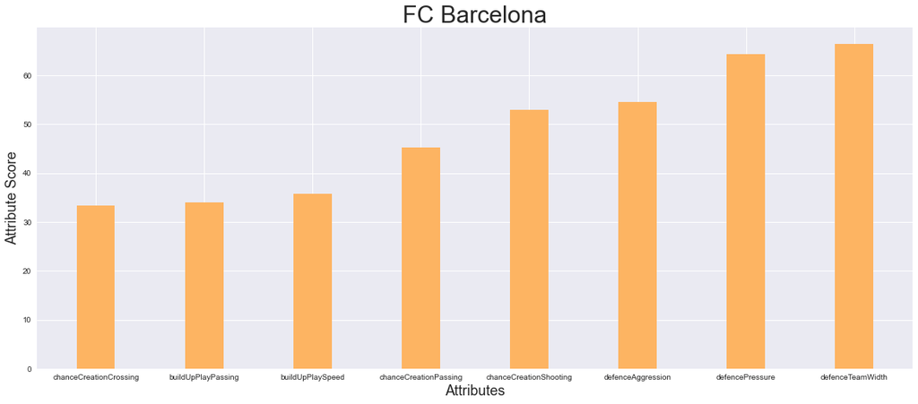

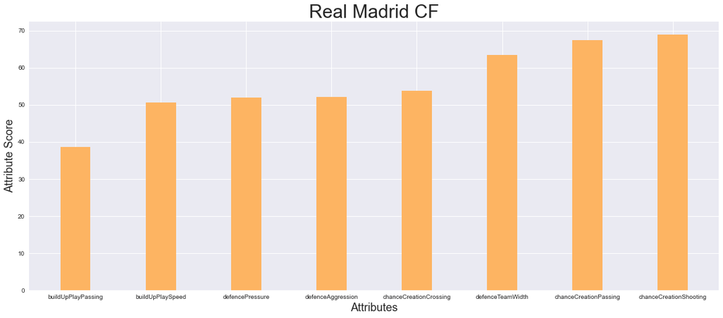

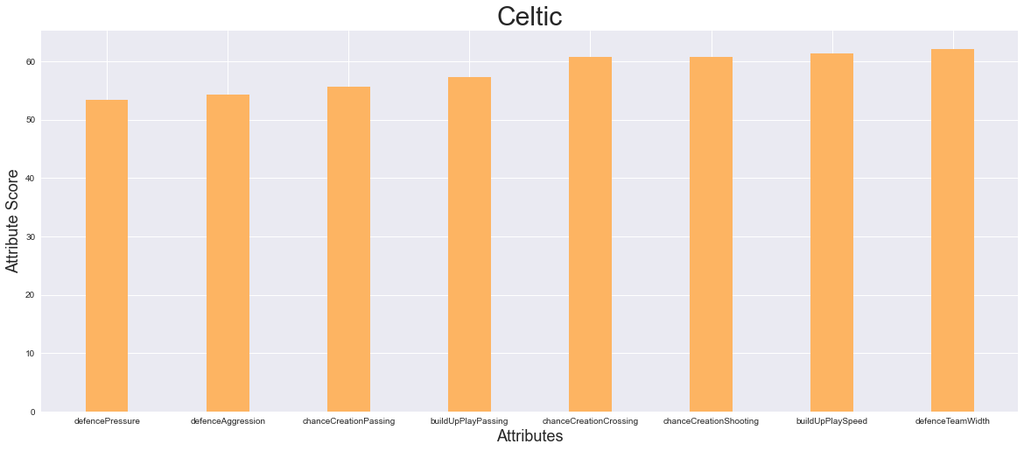

```python
# Using for loop, get mean values of team attributes for each top three teams.
list= top.to_dict().keys()
for team in list:
    x= team_attribute.loc[(team_attribute.team_long_name == team)]
    y= x.mean(numeric_only=True).sort_values().to_dict()

    keys = y.keys()
    values = y.values()

    fig = plt.figure(figsize=(20,8));

    plt.bar(keys, values, color =sns_colors[5] ,width = 0.35);
    plt.title(team, fontsize=30);
    plt.ylabel('Attribute Score', fontsize=18);
    plt.xlabel('Attributes', fontsize=18);
```

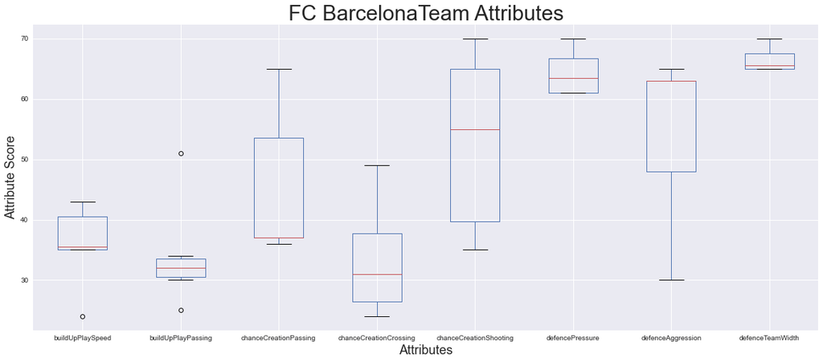

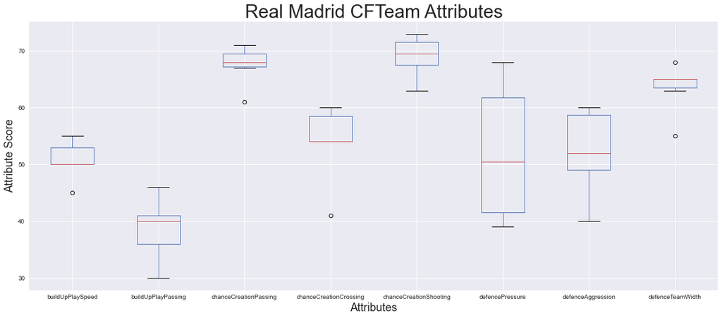

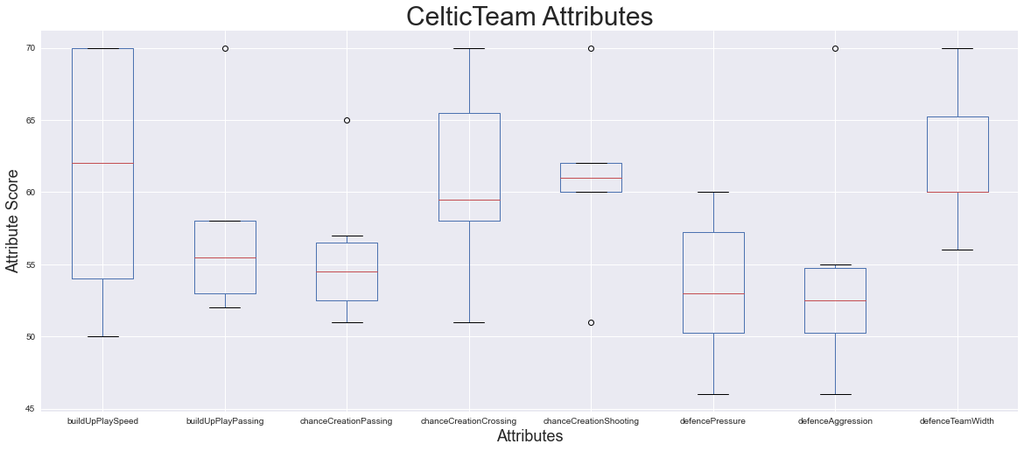

```python
# Use box plot to show the five-number summary for each attribute for each top team.
list= ['FC Barcelona','Real Madrid CF','Celtic']
for item in list:
    x= team_attribute.loc[(team_attribute.team_long_name == item)]
    x.groupby('team_long_name').plot(kind='box', figsize=(20,8));
    plt.title(item + 'Team Attributes', fontsize=30);
    plt.ylabel('Attribute Score', fontsize=18);
    plt.xlabel('Attributes', fontsize=18);
```

### Who is the oldest and the youngest player?

```python
#Youngest player.
df_players['birthday'].max()
```

```
Timestamp('1999-04-24 00:00:00')
```

```python
young_player= df_players.query('birthday == birthday.max()')
print('Youngest Player is:')
young_player
```

```
Youngest Player is:
```

|  | player_id | player_name | birthday | height | weight |
| --- | --- | --- | --- | --- | --- |
| 5176 | 682552 | Jonathan Leko | 1999-04-24 | 182.88 | 141 |

```python
# Oldest player.
df_players['birthday'].min()
```

```
Timestamp('1967-01-23 00:00:00')
```

```python
old_player= df_players.query('birthday == birthday.min()')
print('Oldest Player is:')
old_player
```

```
Oldest Player is:
```

|  | player_id | player_name | birthday | height | weight |
| --- | --- | --- | --- | --- | --- |
| 289 | 39425 | Alberto Fontana | 1967-01-23 | 185.42 | 161 |

### Who is the tallest players?

```python
df_players['height'].max()
```

```
208.28
```

```python
tallest_player= df_players.query('height == height.max()')
print('Tallest Player is:')
tallest_player
```

```
Tallest Player is:
```

|  | player_id | player_name | birthday | height | weight |
| --- | --- | --- | --- | --- | --- |
| 5901 | 148325 | Kristof van Hout | 1987-02-09 | 208.28 | 243 |

### who has the highest and the lowest average of overall rating?

```python
# Highest average of overall rating.
highest_rating= players.groupby('player_name')
highest_rating.overall_rating.mean().sort_values(ascending=False)[:1]
```

```
player_name
Lionel Messi    92.192308
Name: overall_rating, dtype: float64
```

```python
# Lowest average of overall rating.
lowest_rating= players.groupby('player_name')
lowest_rating.overall_rating.mean().sort_values(ascending=False)[-1:]
```

```
player_name
Gianluca D'Angelo    43.75
Name: overall_rating, dtype: float64
```

### How many players use either preferred right or left foot?

```python
players['preferred_foot'].value_counts()
```

```
right    136247
left      44107
Name: preferred_foot, dtype: int64
```

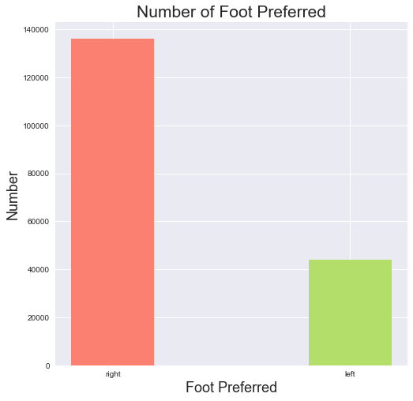

```python
# Plot results using bar chart.
foot= players['preferred_foot'].value_counts().to_dict()
keys = foot.keys()
values = foot.values()

fig = plt.figure(figsize = (8, 8));

plt.bar(keys, values, color =[sns_colors[3], sns_colors[6]], width = 0.35);
plt.xlabel("Foot Preferred", fontsize=18);
plt.ylabel("Number", fontsize=18);
plt.title("Number of Foot Preferred", fontsize=21);
```

### Who made the most penalties?

```python
# Use average.
penalty= players.groupby('player_name')
print('The player who made the most penalties:')
penalty.penalties.mean().sort_values(ascending=False)[:1]
```

```
The player who made the most penalties:
```

```
player_name
Mario Balotelli    89.565217
Name: penalties, dtype: float64
```

### What are the attributes of the 5 best players based on their average overall ratings?

```python
best_players= players.groupby('player_name').overall_rating.mean().sort_values(ascending=False)[:5]
best_players.to_dict().keys()
```

```
dict_keys(['Lionel Messi', 'Cristiano Ronaldo', 'Franck Ribery', 'Andres Iniesta', 'Zlatan Ibrahimovic'])
```

```python
# Drop few not needed columns.
players.drop(['player_id','birthday', 'height','overall_rating','potential', 'weight','gk_diving', 'gk_handling',
       'gk_kicking', 'gk_positioning', 'gk_reflexes'], axis=1, inplace=True)
```

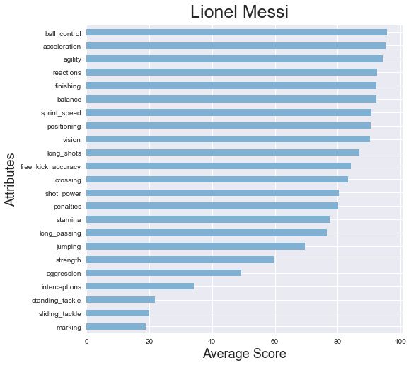

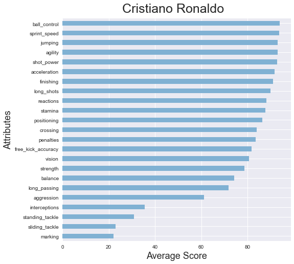

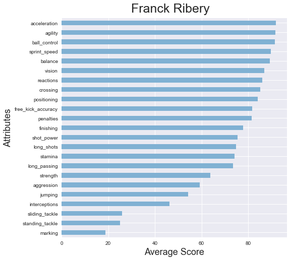

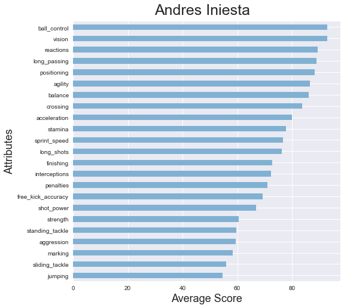

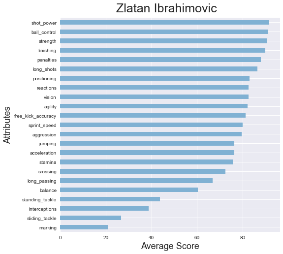

```python
# Using for loop, get mean values of player attributes for each 5 best players.
list= best_players.to_dict()
for player in list:
    x= players.loc[(players.player_name == player)]
    y= x.mean(numeric_only=True).sort_values()
    colors= sns_colors[4]
    y.plot(kind='barh', color=colors, figsize=(8,8));
    plt.figtext(.5,.9,player, fontsize=25, ha='center');
    plt.xlabel('Average Score', fontsize=18);
    plt.ylabel('Attributes', fontsize=18);
    plt.show();
```

## Conclusions

From the soccer datasets provided, we can conclude the following:\

1. Season 2008/2009 had the highest number of matches.
2. England, France, and Spain with their respective leagues hosted the highest number of matches throughout the 8 seasons.
3. 'FC Barcelona','Real Madrid CF','Celtic' are the most victorious teams throughout the 8 seasons.
4. Teams who play on their homeland are more likely to win by 45.87%.
5. Paris Saint-German has made the highest performance progress throughout the 8 seasons.
6. Features that mostly lead teams to victory differs among diferent teams. But for the top three teams these are their highest attribute mean score:
   - FC Barcelona: defence pressure and defence team width.
   - Real Madrid CF: chance creation passing and chance creation shooting.
   - Celtic: build up play speed and defence team width.
7. Jonathan Leko is the youngest player, while Alberto Fontana is the oldest player.
8. Kristof van Hout is the tallest player.
9. Lionel Messi had the highest average overall rating, while Gianluca D'Angelo has the lowest average overall rating.
10. Number of players who prefere to use their right foot is greater than those who use their left foot.
11. Mario Balotelli made the most penalties on average.
12. Combined top attributes differs for each player.
    - Lionel Messi: ball control, acceleration, and agility.
    - Cristiano Ronaldo: ball control, sprint speed, and jumping.
    - Frank Ribery: acceleration, agility, and ball control.
    - Andres Iniesta: ball control, vision, and reactions.
    - Zlatan Ibrahimovic: shot power, ball control, and strength.

## Limitation:

- There is no explanation for attributes in both teams and players.
- Duplicated team names with different id numbers.
- Duplicated players name but with different set of data. Also, in player_name column there were some players with only first name or surname.
- The player dataset doesn't include what team each player belonged to.